# Lesson 6b. Data Exploration and Plotting in R - Swainson’s Thrush Data - Adding Bootstrap

L Leston

2023-07-27

**Learning Objectives**

The purpose of this lesson is to demonstrate the concept of bootstrapping when you have enough data to do so.

**Learning Outcomes**

In addition to the outcomes from Lesson 6 below, the student will generate bootstrap sample datasets, run a model and store model results from each sample, then obtain predictions from each stored model run’s coefficients, and display those predictions in a *matrix plot*.

The student will be able to manipulate data frames to get data ready for plotting.

The student will explore how data within a single variable is distributed (*histogram*).

The student will be able to generate box plots to compare values of a variable within two or more categorical groups (*box, bar plots*).

The student will be able to generate plots showing how one numeric variable’s values change with the values of another numeric variable (*scatter plot*).

The student will be able to run a simple *model* describing a theoretical relationship between two or more variables. Model examples include a *t-test*, a *regression*, an *analysis of variance (ANOVA)*, and a *generalized linear model*.

The student will merge predictor data (*independent or explanatory* variables for each site) to bird count data to test for a relationship between bird abundance (the *dependent variable*) and an *independent variable*.

**Wild Trax data set: BU_Hart(s)-SWTH-NorthVsSouthSongRate-BU_2021_main_report**

The data we are looking at consist of detections of SWTH per recording at each ARU station. There is one recording per hour within a 24-hour period at each station on a particular date, with one or more individuals per species detected per recording. The intent is to look at how detections of SWTH change over a 24-hour cycle and ideally how the relationship between time of day and song activity varies with latitude. *Note*: not all of the recordings have been transcribed yet, so there are some recordings with “NONE” as the species detected.

**Reading Data into R**

Now we will read in the data using a *function* in R called **read.csv()**:

```r
library(dplyr)
library(tidyr)
#library(ggplot2)
ToD_T_W<-read.csv("point counts/BU_Hart(s)-SWTH-NorthVsSouthSongRate-BU_2021_main_report.csv", header=TRUE)
#R looks for data file in point counts folder in same directory as this R script. File address is a relative file path.
```

R has taken a spreadsheet or table stored in a CSV file and saved it as an object in R called a *data frame*. The data frame stores the data we imported in a similar manner to a spreadsheet or table: observations as rows, variables or data types as columns. We will now examine the contents of the data frame *ToD_T_W* that we have created.

```r
str(ToD_T_W)
```

```
## 'data.frame':    5820 obs. of  30 variables:
##  $ organization               : chr  "BU" "BU" "BU" "BU" ...
##  $ project_id                 : int  657 657 657 657 657 657 657 657 657 657 ...
##  $ location                   : chr  "BG-8-11" "BG-8-11" "BG-8-11" "BG-8-11" ...
##  $ location_id                : int  35076 35076 35076 35076 35076 35076 35076 35076 35076 35076 ...
##  $ location_buffer_m          : logi  NA NA NA NA NA NA ...
##  $ longitude                  : num  -122 -122 -122 -122 -122 ...
##  $ latitude                   : num  59.4 59.4 59.4 59.4 59.4 ...
##  $ equipment_make             : chr  "Wildlife Acoustics" "Wildlife Acoustics" "Wildlife Acoustics" "Wildlife Acoustics" ...
##  $ recording_id               : int  204078 203990 203589 204027 203732 203903 203726 203806 203988 203588 ...
##  $ recording_date_time        : chr  "2016-06-10 15:00:00" "2016-06-10 22:23:00" "2016-06-10 23:23:00" "2016-06-11 02:00:00" ...
##  $ task_id                    : int  173237 173145 172744 173182 172887 173058 172881 172961 173143 172743 ...
##  $ aru_task_status            : chr  "Transcribed" "New" "New" "New" ...
##  $ task_duration              : chr  "60s" "60s" "60s" "60s" ...
##  $ task_method                : chr  "None" "None" "None" "None" ...
```

[output cut: 16 more lines]

Let’s get rid of the recordings which have not yet been transcribed.

```r
nrow(ToD_T_W[ToD_T_W$species_code=="NONE",])#3242
```

```
## [1] 3242
```

```r
nrow(ToD_T_W[!ToD_T_W$species_code=="NONE",])#2578
```

```
## [1] 2578
```

```r
nrow(ToD_T_W[ToD_T_W$observer_user_id==-1,])#2278
```

```
## [1] 2278
```

```r
nrow(ToD_T_W[!ToD_T_W$observer_user_id==-1,])#3542
```

```
## [1] 3542
```

```r
levels(as.factor(ToD_T_W$aru_task_status))
```

```
## [1] "Bad Weather" "In Progress" "New"         "Transcribed"
```

```r
#"Bad Weather" "In Progress" "New"         "Transcribed"
nrow(ToD_T_W[ToD_T_W$aru_task_status=="Transcribed",])#3464
```

```
## [1] 3464
```

```r
nrow(ToD_T_W[!ToD_T_W$aru_task_status=="Transcribed",])#2356
```

```
## [1] 2356
```

```r
ToD_T_WTrans<-ToD_T_W%>%filter(aru_task_status=="Transcribed")
```

Our observations will be individual recordings. Each observation will have a count for each possible species in the dataset. We start by taking the variable *individual_count*, which is a character string, and converting it to a number variable. *Note*: the variable *individual_order* may be better as *max(individual_order)* will give us the number of distinct individuals thought to be in a recording.

```r
ToD_T_W.birdsonly<-ToD_T_WTrans
ToD_T_W.birdsonly$individual_count<-ifelse(ToD_T_W.birdsonly$individual_count %in% c("CI 1","CI 2","CI 3","TMTT"), "0", ToD_T_W.birdsonly$individual_count)

ToD_T_W.birdsonly$individual_count<-ifelse(ToD_T_W.birdsonly$species_common_name == "NONE", "0", ToD_T_W.birdsonly$individual_count)

levels(as.factor(ToD_T_W.birdsonly$individual_count))
```

```
## [1] "0" "1" "2"
```

```r
ToD_T_W.birdsonly$individual_count<-as.integer(ToD_T_W.birdsonly$individual_count)

#Alternatively, you could do this
ToD_T_W.birdsonly<-ToD_T_WTrans%>%
  mutate(individual_count = case_when(individual_count=="1" ~ 1,
                                individual_count=="2" ~ 2,
                                individual_count=="3" ~ 3,
                                individual_count=="4" ~ 4,
                                individual_count=="8" ~ 8,
                                species_code=="NONE" ~ 0,
                                individual_count=="0" ~ 0,
                                individual_count=="CI 1" ~ 0,
                                individual_count=="CI 2"~ 0,
                                individual_count=="CI 3"~ 0,
                                individual_count=="TMTT"~ 0))
```

Now that we have counts of individual species, we can try summarizing the data using the variable *individual_order*.

**Manipulating data using *tidyverse* functions**

Summarize individual counts of each species at each site in each recording using *dplyr* and *tidyr* while keeping everything on a single 2-d data frame.

```r
songs_per_recording<-ToD_T_W.birdsonly%>%
  group_by(location, recording_date_time, species_code, latitude, longitude)%>%
  summarize(songactivity=sum(individual_count))%>%
  pivot_wider(names_from="species_code", values_from="songactivity")%>%
  mutate(across(where(is.numeric), ~replace(., is.na(.), 0)))%>%
  select("location", "recording_date_time", "latitude", "longitude", "SWTH")
write.csv(songs_per_recording, file="output/SWTHsongs_per_recording.csv")

indivs_per_recording<-ToD_T_W.birdsonly%>%
  group_by(location, recording_date_time, species_code, latitude, longitude)%>%
  summarize(indivs=max(individual_order))%>%
  pivot_wider(names_from="species_code", values_from="indivs")%>%
  mutate(across(where(is.numeric), ~replace(., is.na(.), 0)))%>%
  select("location", "recording_date_time", "latitude", "longitude", "SWTH")
write.csv(indivs_per_recording, file="output/SWTHindivs_per_recording.csv")
```

Let’s create some time variables for each recording.

```r
library(lubridate)

songs_per_recording$Hour<-format(as.POSIXct(songs_per_recording$recording_date_time), format = "%H")
songs_per_recording$Minute<-format(as.POSIXct(songs_per_recording$recording_date_time), format = "%M")
songs_per_recording$timeNumeric<-as.integer(songs_per_recording$Hour)+(as.integer(songs_per_recording$Minute)/60)

songs_per_recording$JulianDay<-yday(songs_per_recording$recording_date_time)
write.csv(songs_per_recording, file="output/SWTHsongs_per_recording.csv")

indivs_per_recording$Hour<-format(as.POSIXct(indivs_per_recording$recording_date_time), format = "%H")
indivs_per_recording$Minute<-format(as.POSIXct(indivs_per_recording$recording_date_time), format = "%M")
indivs_per_recording$timeNumeric<-as.integer(indivs_per_recording$Hour)+(as.integer(indivs_per_recording$Minute)/60)

indivs_per_recording$JulianDay<-yday(indivs_per_recording$recording_date_time)
write.csv(indivs_per_recording, file="output/SWTHindivs_per_recording.csv")
```

**Histograms**

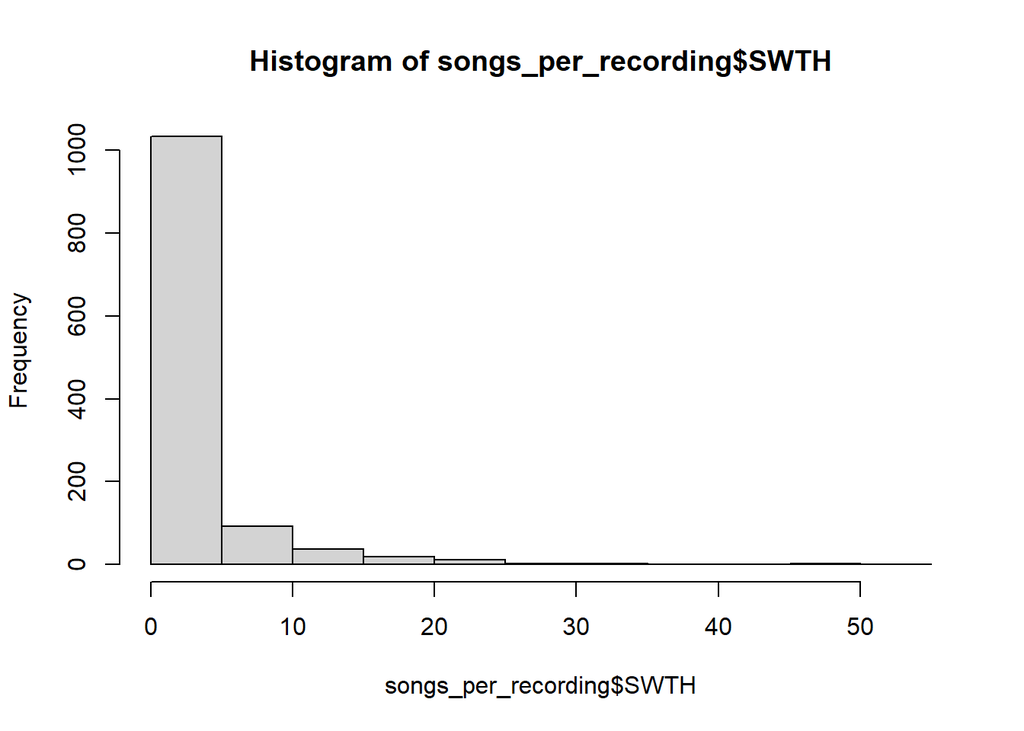

```r
hist(songs_per_recording$SWTH)
```

```r
print(paste0("Mean SWTH song activity per recording: ", mean(songs_per_recording$SWTH)))
```

```
## [1] "Mean SWTH song activity per recording: 1.94171523730225"
```

```r
print(paste0("Variance in SWTH song activity per recording: ", var(songs_per_recording$SWTH)))
```

```
## [1] "Variance in SWTH song activity per recording: 26.848266722176"
```

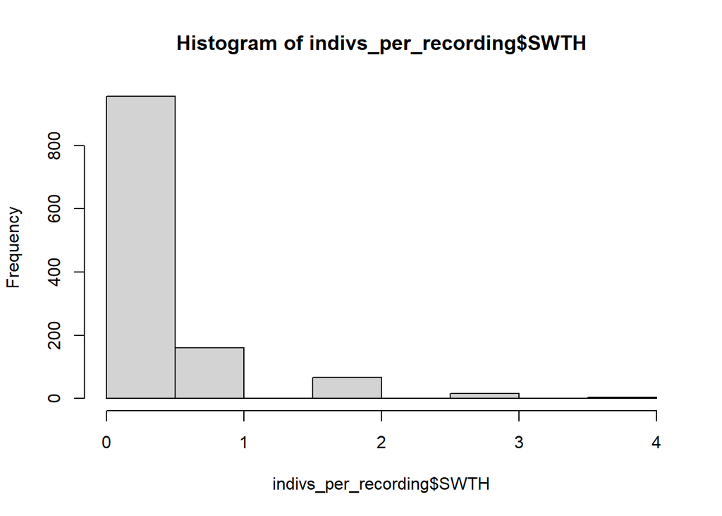

```r
hist(indivs_per_recording$SWTH)
```

```r
print(paste0("Mean SWTH individuals per recording: ", mean(indivs_per_recording$SWTH)))
```

```
## [1] "Mean SWTH individuals per recording: 0.295587010824313"
```

```r
print(paste0("Variance in SWTH individuals per recording: ", var(indivs_per_recording$SWTH)))
```

```
## [1] "Variance in SWTH individuals per recording: 0.435055509297807"
```

```r
nlevels(as.factor(songs_per_recording$latitude))#4
```

```
## [1] 4
```

```r
levels(as.factor(songs_per_recording$latitude))
```

```
## [1] "53.789867" "59.411708" "59.417149" "60.03968"
```

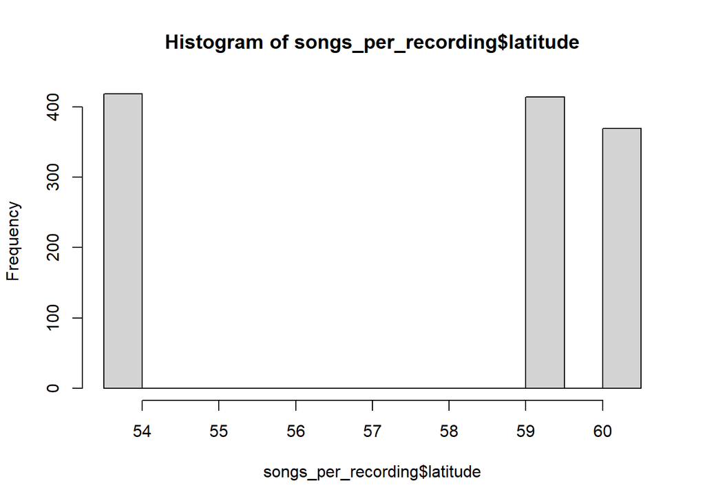

```r
#"53.789867" "59.411708" "59.417149" "60.03968"
hist(songs_per_recording$latitude)
```

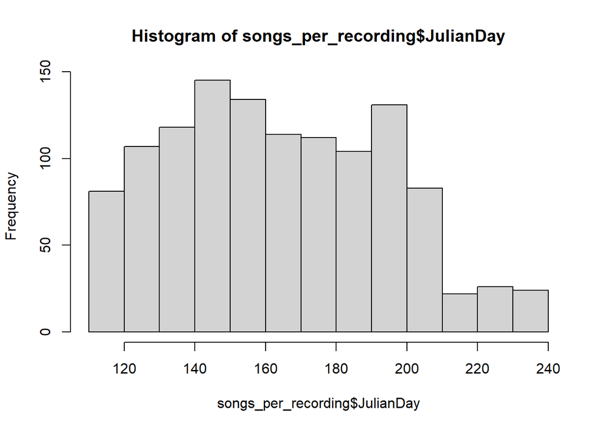

```r
hist(songs_per_recording$JulianDay)
```

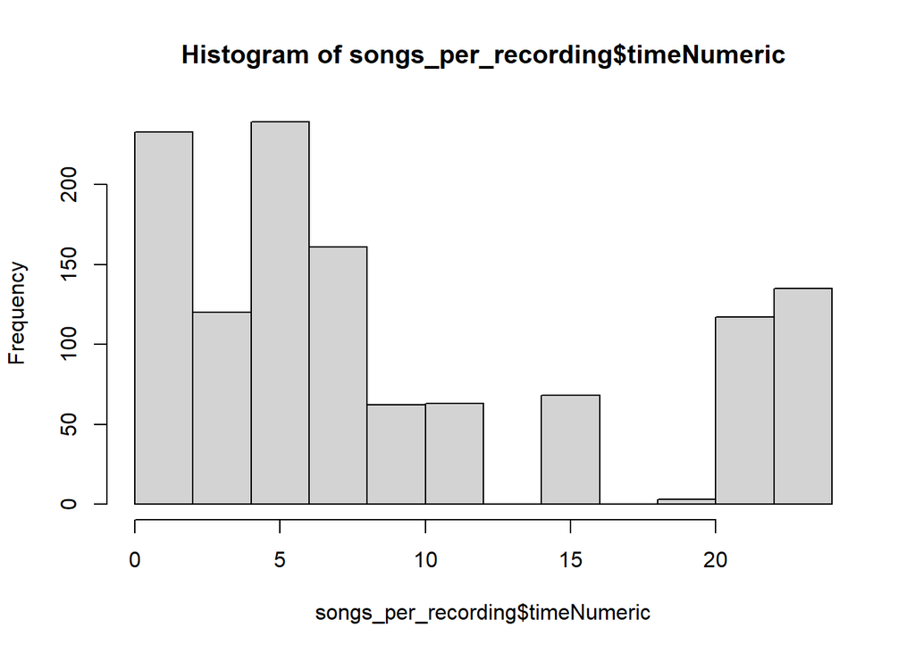

```r
hist(songs_per_recording$timeNumeric)
```

**Box and Bar Plots**

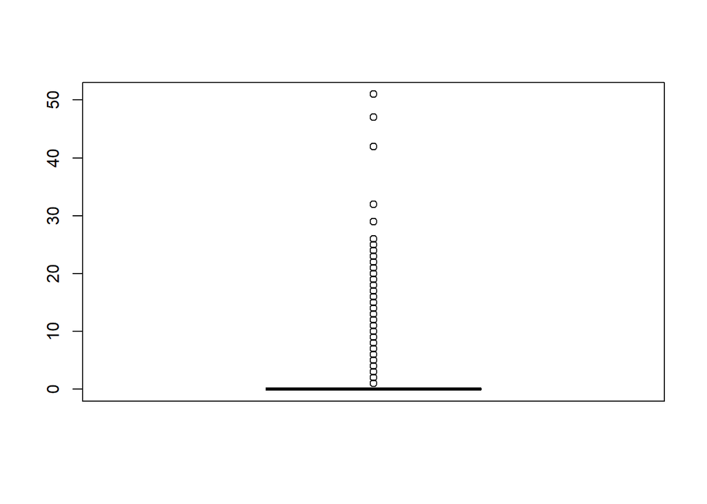

```r
boxplot(songs_per_recording$SWTH)
```

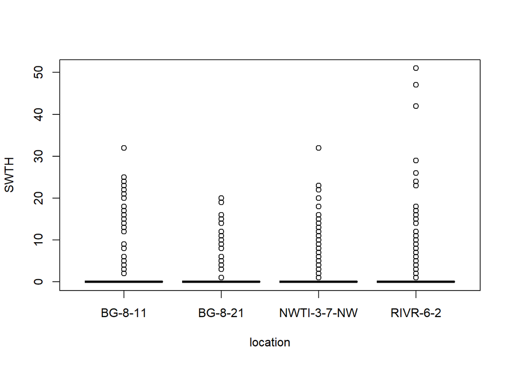

```r
boxplot(SWTH~location,
        data=songs_per_recording)
```

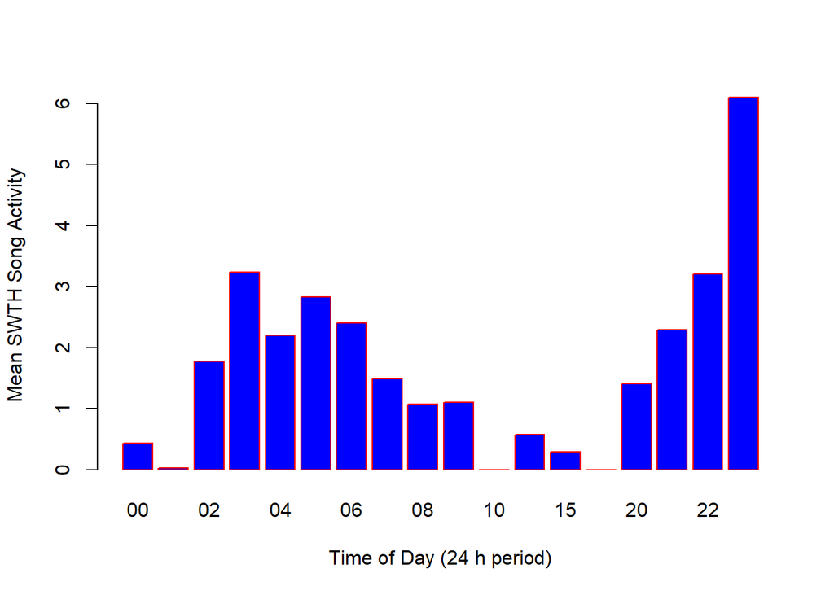

```r
swth_summ<-songs_per_recording%>%
  group_by(Hour)%>%
  summarize(SWTH=mean(SWTH))
barplot(swth_summ$SWTH,
  xlab="Time of Day (24 h period)",
  names.arg=levels(as.factor(songs_per_recording$Hour)),
  ylab="Mean SWTH Song Activity",
  border="red",
  col="blue")
```

**Scatter Plots**

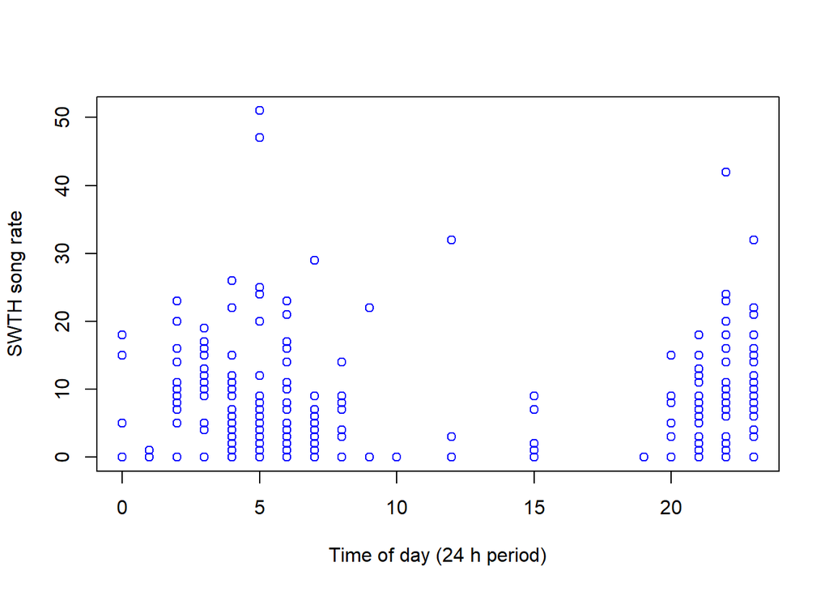

```r
plot(songs_per_recording$Hour,
     songs_per_recording$SWTH,
     ylab="SWTH song rate",
     xlab="Time of day (24 h period)",
     col="blue")
```

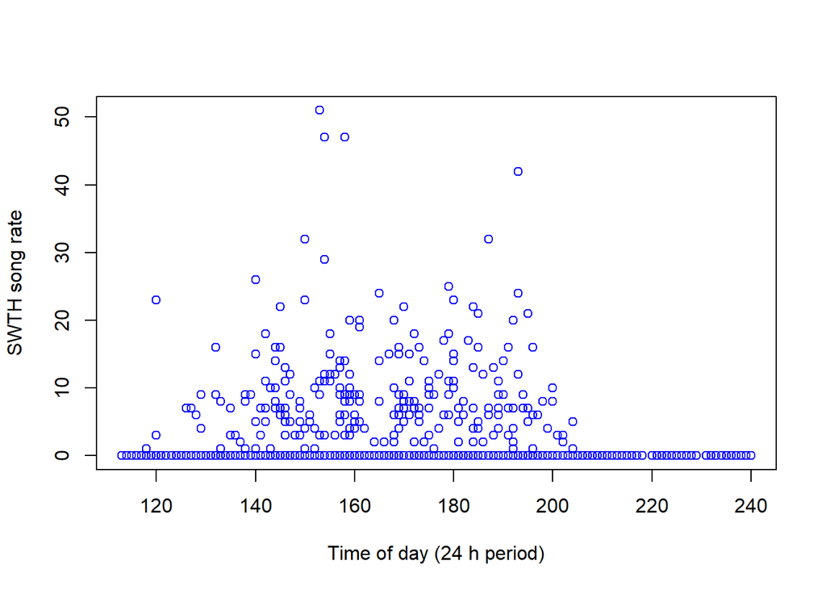

```r
plot(songs_per_recording$JulianDay,
     songs_per_recording$SWTH,
     ylab="SWTH song rate",
     xlab="Time of day (24 h period)",
     col="blue")
```

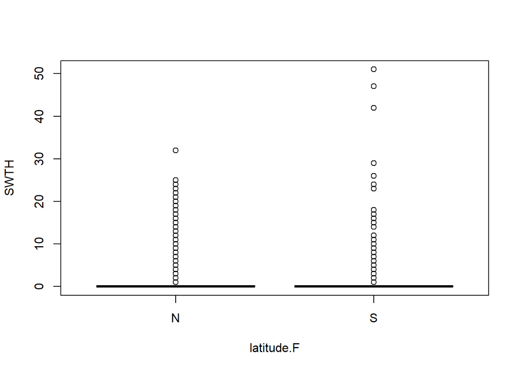

```r
songs_per_recording$latitude.F<-as.factor(ifelse(songs_per_recording$latitude<55,"S","N"))
boxplot(SWTH~latitude.F,
        data=songs_per_recording)
```

**Run a Simple Model**

Data exploration suggested that Swainson’s Thrush song activity varied as a quadratic function of Julian day.

```r
songs_per_recording$JDAY<-(songs_per_recording$JulianDay-mean(songs_per_recording$JulianDay))/sd(songs_per_recording$JulianDay)
songs_per_recording$JDAY2<-songs_per_recording$JDAY^2

mod<-lm(SWTH~JDAY+JDAY2, data=songs_per_recording)
summary(mod)
```

```
##
## Call:
## lm(formula = SWTH ~ JDAY + JDAY2, data = songs_per_recording)
##
## Residuals:
##    Min     1Q Median     3Q    Max
## -3.032 -2.624 -1.745  0.083 48.256
##
## Coefficients:
##             Estimate Std. Error t value Pr(>|t|)
## (Intercept)   3.0098     0.2000  15.051  < 2e-16 ***
## JDAY          0.3094     0.1504   2.057   0.0399 *
## JDAY2        -1.0689     0.1368  -7.814  1.2e-14 ***
## ---
## Signif. codes:  0 '***' 0.001 '**' 0.01 '*' 0.05 '.' 0.1 ' ' 1
##
## Residual standard error: 5.058 on 1198 degrees of freedom
## Multiple R-squared:  0.04852,    Adjusted R-squared:  0.04694
## F-statistic: 30.55 on 2 and 1198 DF,  p-value: 1.149e-13
```

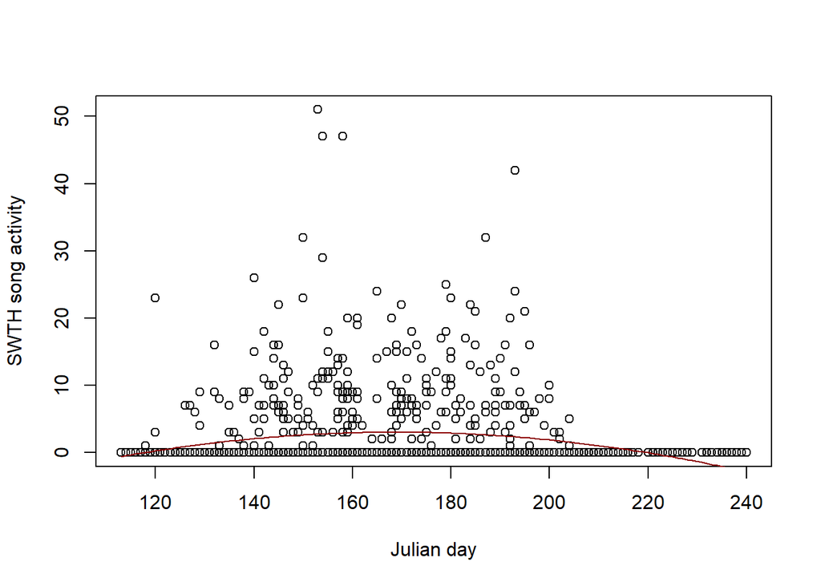

```r
#Get predicted values from linear regression
preds<-predict(mod, songs_per_recording, se.fit = FALSE, scale = NULL, df = Inf,
        interval = c("prediction"),
        level = 0.95, type = c("response"))

songs_per_recording.P<-cbind(songs_per_recording,preds)

songs_per_recording.P<-songs_per_recording.P%>%
  arrange(JulianDay)
plot(songs_per_recording.P$JulianDay,
     songs_per_recording.P$SWTH,
     xlab="Julian day",
     ylab="SWTH song activity")
lines(songs_per_recording.P$JulianDay,
     songs_per_recording.P$fit, col="darkred")
```

Regression results also suggested that Swainson’s Thrush song activity varied as a quadratic function of Julian day, although a *bimodel distribution* is another possibility, and Julian day only explained a small amount of variance.

How well does the data meet the statistical assumptions of regression?

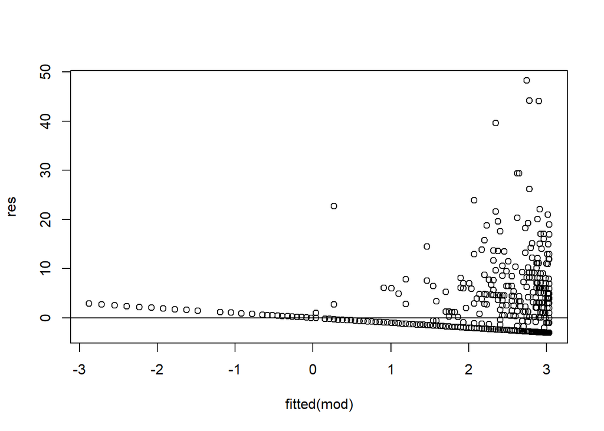

```r
res<-resid(mod)
plot(fitted(mod), res)
abline(0,0)
```

There is a lot of variance heterogeneity (bad!) since the *residuals* vary a lot more as the size of predicted values of song activity increase.

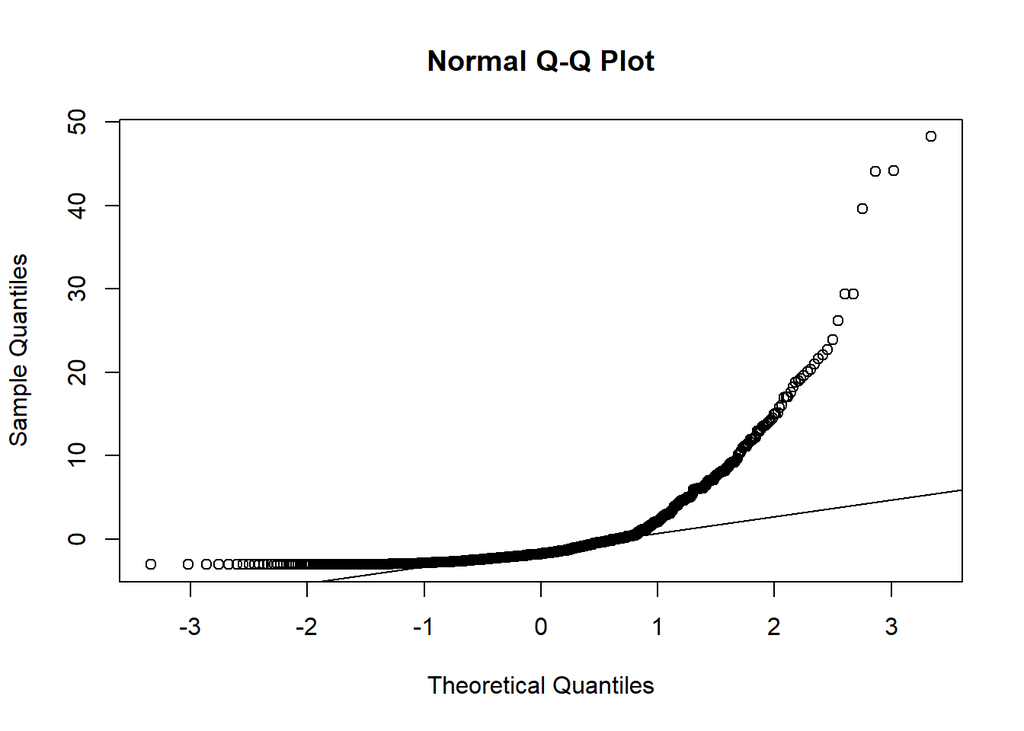

```r
qqnorm(res)#create a Q-Q plot for the residuals
qqline(res)#add a straight diagonal line to the plot
```

Larger predicted values’ residuals deviate from the Q-Q line (bad!).

On top of that, we know that there are multiple observations per site and those will be correlated with other observations from the same site.

We can try transforming the response variable to see if it improves the regression results but data independence will still be an issue.

```r
songs_per_recording$SWTH.sq<-sqrt(songs_per_recording$SWTH)
songs_per_recording$SWTH.log<-log(songs_per_recording$SWTH+0.1)

mod2<-lm(SWTH.sq~JDAY+JDAY2, data=songs_per_recording)
summary(mod2)
```

```
##
## Call:
## lm(formula = SWTH.sq ~ JDAY + JDAY2, data = songs_per_recording)
##
## Residuals:
##     Min      1Q  Median      3Q     Max
## -0.9087 -0.7900 -0.5269  0.0764  6.3162
##
## Coefficients:
##             Estimate Std. Error t value Pr(>|t|)
## (Intercept)  0.90254    0.04820  18.724   <2e-16 ***
## JDAY         0.08859    0.03626   2.444   0.0147 *
## JDAY2       -0.31477    0.03297  -9.546   <2e-16 ***
## ---
## Signif. codes:  0 '***' 0.001 '**' 0.01 '*' 0.05 '.' 0.1 ' ' 1
##
## Residual standard error: 1.219 on 1198 degrees of freedom
## Multiple R-squared:  0.07071,    Adjusted R-squared:  0.06915
## F-statistic: 45.58 on 2 and 1198 DF,  p-value: < 2.2e-16
```

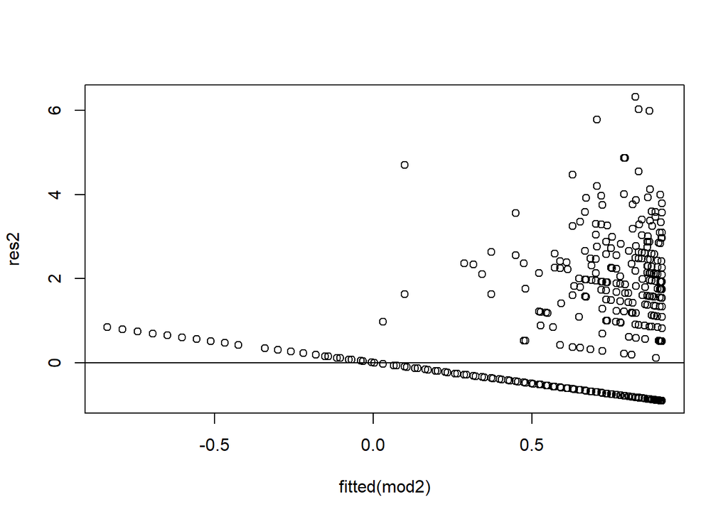

```r
res2<-resid(mod2)
plot(fitted(mod2), res2)
abline(0,0)
```

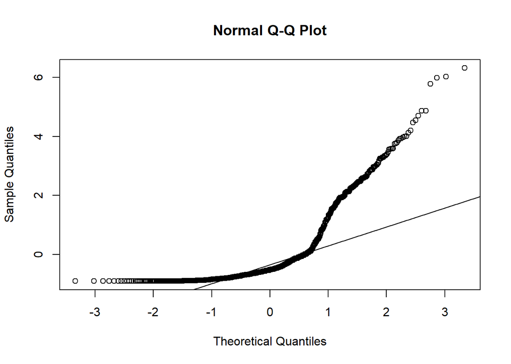

```r
qqnorm(res2)
qqline(res2)
```

```r
mod3<-lm(SWTH.log~JDAY+JDAY2, data=songs_per_recording)
summary(mod3)
```

```
##
## Call:
## lm(formula = SWTH.log ~ JDAY + JDAY2, data = songs_per_recording)
##
## Residuals:
##     Min      1Q  Median      3Q     Max
## -1.3438 -1.1723 -0.7830  0.0893  5.2765
##
## Coefficients:
##             Estimate Std. Error t value Pr(>|t|)
## (Intercept) -0.96732    0.06702 -14.433   <2e-16 ***
## JDAY         0.12640    0.05041   2.507   0.0123 *
## JDAY2       -0.45965    0.04585 -10.025   <2e-16 ***
## ---
## Signif. codes:  0 '***' 0.001 '**' 0.01 '*' 0.05 '.' 0.1 ' ' 1
##
## Residual standard error: 1.695 on 1198 degrees of freedom
## Multiple R-squared:  0.07741,    Adjusted R-squared:  0.07587
## F-statistic: 50.26 on 2 and 1198 DF,  p-value: < 2.2e-16
```

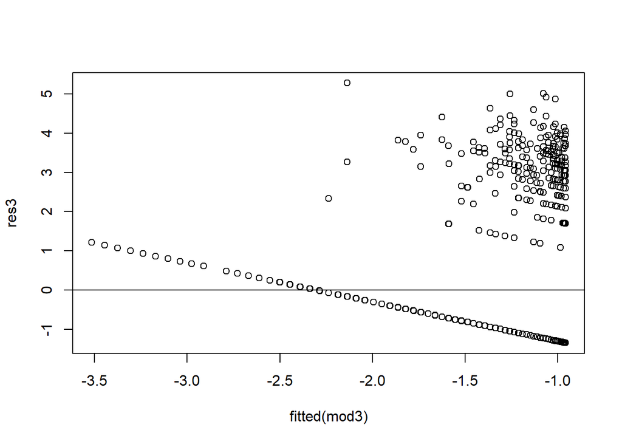

```r
res3<-resid(mod3)
plot(fitted(mod3), res3)
abline(0,0)
```

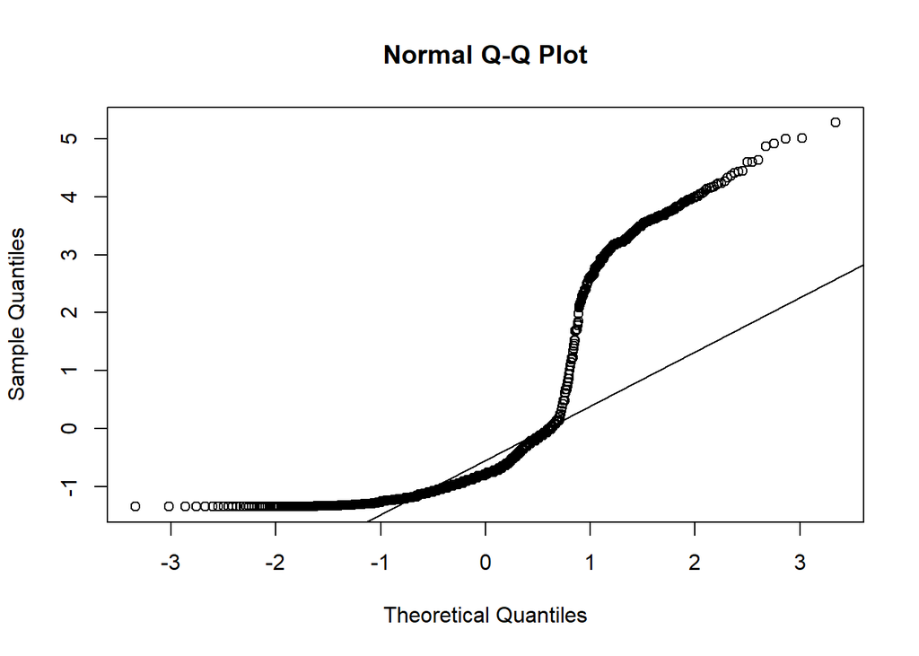

```r
qqnorm(res3)
qqline(res3)
```

Square-root transforming or log-transforming the data does not improve the model output much. R-squared values are slightly higher after transformation but variance is still very heterogeneous.

A *generalized linear model* that assumes a non-normal error distribution in song activity might fit better.

```r
mod4<-glm(SWTH~JDAY+JDAY2, data=songs_per_recording, family=quasipoisson(link = "log"))
summary(mod4)
```

```
##
## Call:
## glm(formula = SWTH ~ JDAY + JDAY2, family = quasipoisson(link = "log"),
##     data = songs_per_recording)
##
## Deviance Residuals:
##     Min       1Q   Median       3Q      Max
## -2.8372  -2.2445  -1.3850  -0.5133  13.9938
##
## Coefficients:
##             Estimate Std. Error t value Pr(>|t|)
## (Intercept)  1.38853    0.09167  15.146  < 2e-16 ***
## JDAY         0.13773    0.11706   1.177     0.24
## JDAY2       -1.20346    0.15249  -7.892 6.68e-15 ***
## ---
## Signif. codes:  0 '***' 0.001 '**' 0.01 '*' 0.05 '.' 0.1 ' ' 1
##
## (Dispersion parameter for quasipoisson family taken to be 11.95158)
##
##     Null deviance: 8648.6  on 1200  degrees of freedom
## Residual deviance: 7369.4  on 1198  degrees of freedom
## AIC: NA
##
## Number of Fisher Scoring iterations: 7
```

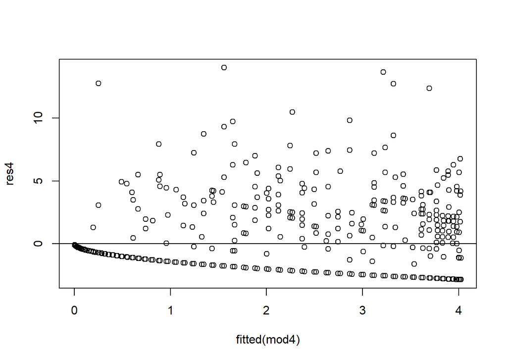

```r
res4<-resid(mod4)
plot(fitted(mod4), res4)
abline(0,0)
```

```r
pseudo.R2<-(mod4$null.deviance-mod4$deviance)/mod4$null.deviance
```

There is some variance heterogeneity still but less than with linear regression and the pseudo-R2 (proportion of explained deviance) 0.147906 is greater than the R2 explained by the regression.

Data exploration suggests that Swainson’s Thrush song activity varies as a more complex function of day and night. Use a more complex model like a generalized additive model or a circular function.

*Also keep in mind*: all observations in these regression models are assumed to be independent but they come from four sites with multiple days in a row at a site. So mixed-effects models might be appropriate.

```r
library(mgcv)
library(gamm4)
thetaval=(var(songs_per_recording$SWTH)/mean(songs_per_recording$SWTH))

songs_per_recording$TIME<-(songs_per_recording$timeNumeric-mean(songs_per_recording$timeNumeric))/sd(songs_per_recording$timeNumeric)

GAM1 <- gamm4(SWTH ~s(JDAY, k = 5, bs = "cs") + s(TIME, k = 5, bs = "cs"), random=~(1|location), data=songs_per_recording, family=negbin(theta=thetaval, link="log"))

coef.gammB<-coef(GAM1$gam)
#model.matrix(GAM1$gam)
```

A more complex GAM where the effects of time of day and time of season can vary with latitude.

```r
GAM2 <- gamm4(SWTH ~latitude.F+ s(JDAY, k = 5, bs = "cs", by=latitude.F) + s(TIME, k = 7, bs = "cs", by=latitude.F), random=~(1|location), data=songs_per_recording, family=negbin(theta=thetaval, link="log"))

coef.gammB2<-coef(GAM2$gam)
#model.matrix(GAM2$gam)
coef.gammB2
```

```
##           (Intercept)           latitude.FS s(JDAY):latitude.FN.1
##           -1.92455474           -0.11865978            4.31862922
## s(JDAY):latitude.FN.2 s(JDAY):latitude.FN.3 s(JDAY):latitude.FN.4
##            4.61834953           -2.12601818          -42.67536664
## s(JDAY):latitude.FS.1 s(JDAY):latitude.FS.2 s(JDAY):latitude.FS.3
##            3.09987740            1.93113421           -0.06470633
## s(JDAY):latitude.FS.4 s(TIME):latitude.FN.1 s(TIME):latitude.FN.2
##          -20.70805847            1.01651237            1.06548756
## s(TIME):latitude.FN.3 s(TIME):latitude.FN.4 s(TIME):latitude.FN.5
##            0.30961744           -0.02500996            1.12847453
## s(TIME):latitude.FN.6 s(TIME):latitude.FS.1 s(TIME):latitude.FS.2
##            1.68554771            4.69442525            5.86162751
## s(TIME):latitude.FS.3 s(TIME):latitude.FS.4 s(TIME):latitude.FS.5
##            3.53982472            4.18962833            7.15684104
## s(TIME):latitude.FS.6
##           -0.23263576
```

Compare model fits.

```r
AIC(GAM1$mer, GAM2$mer)
```

```
##          df      AIC
## GAM1$mer  5 6085.371
## GAM2$mer  8 5644.204
```

The second model has a lower AIC value and presumably a better relative fit, suggesting that the effect of Julian day and / or of time of day/night varies between northern and southern Alberta.

We can also check output from GAMs for potential data violations.

```r
print("GAM1 Check:")
```

```
## [1] "GAM1 Check:"
```

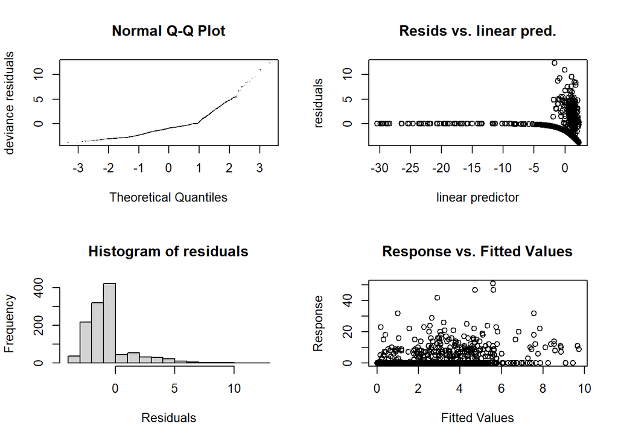

```
##
## 'gamm' based fit - care required with interpretation.
## Checks based on working residuals may be misleading.
## Basis dimension (k) checking results. Low p-value (k-index<1) may
## indicate that k is too low, especially if edf is close to k'.
##
##           k'  edf k-index p-value
## s(JDAY) 4.00 3.96    0.79  <2e-16 ***
## s(TIME) 4.00 3.98    0.86   0.055 .
## ---
## Signif. codes:  0 '***' 0.001 '**' 0.01 '*' 0.05 '.' 0.1 ' ' 1
```

```r
gam.check(GAM1$gam)
```

```r
print("GAM2 Check:")
```

```
## [1] "GAM2 Check:"
```

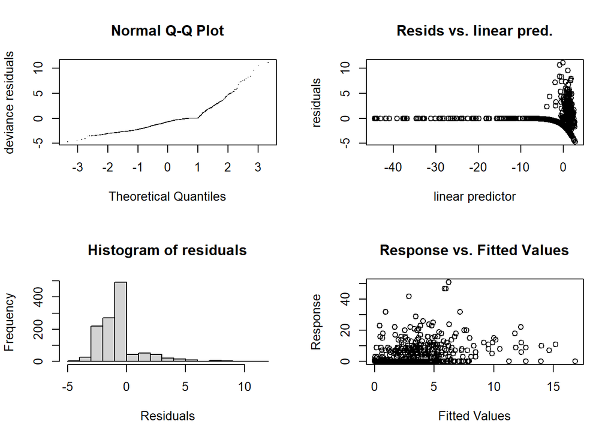

```
##
## 'gamm' based fit - care required with interpretation.
## Checks based on working residuals may be misleading.
## Basis dimension (k) checking results. Low p-value (k-index<1) may
## indicate that k is too low, especially if edf is close to k'.
##
##                       k'  edf k-index p-value
## s(JDAY):latitude.FN 4.00 3.95    0.83  <2e-16 ***
## s(JDAY):latitude.FS 4.00 3.90    0.83   0.005 **
## s(TIME):latitude.FN 6.00 5.56    0.88   0.190
## s(TIME):latitude.FS 6.00 5.67    0.88   0.210
## ---
## Signif. codes:  0 '***' 0.001 '**' 0.01 '*' 0.05 '.' 0.1 ' ' 1
```

```r
gam.check(GAM2$gam)
```

Create a prediction dataset for GAMs

```r
timeNumeric=seq(from=0,to=23.95,by=0.05)
JulianDay=seq(from=113,to=240,by=1)
TIME=(timeNumeric-mean(timeNumeric))/sd(timeNumeric)
JDAY=(JulianDay-mean(JulianDay))/sd(JulianDay)

#songs_per_recording[songs_per_recording$timeNumeric==5,]
swth.tsss.jd<-expand.grid(intercept=1,
                             latitude.F=c("N","S"),
                             TIME=-0.5254806, #scaled value associated with timeNumeric=5.00
                             JDAY=as.numeric(levels(as.factor(JDAY)))
)

#get model matrix for GAM2 based on these variables in prediction dataset
swth.tsss.jdmm <- model.matrix(GAM2$gam, swth.tsss.jd)

## predict and apply inverse link function: this gives a new matrix
swth.gam.pred <- (exp(swth.tsss.jdmm %*% coef.gammB2))#take antilog?
Preds<-data.frame(swth.gam.pred)
```

Plot predicted relationship between Swainson’s Thrush activity at 5 AM over the season in both northern and southern Alberta.

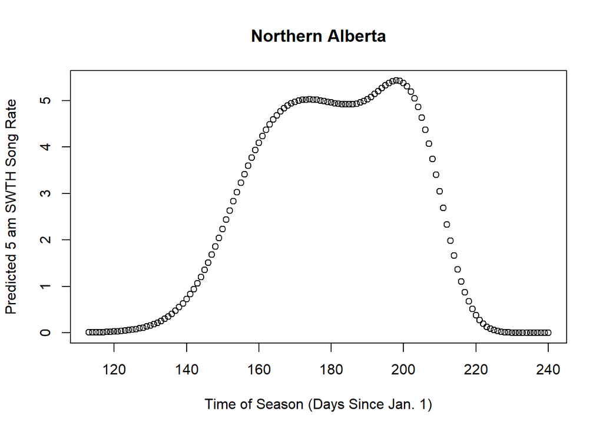

```r
plotData<-cbind(swth.tsss.jd, Preds)
plotData<-data.frame(plotData)
#write.csv(plotData, file="output/GAMdatacheck.csv")
plotDataN.time5<-plotData%>%
  filter(latitude.F=="N")
plotDataN.time5$timeNumeric<-5.0
plotDataN.time5$JulianDay<-JulianDay

plot(plotDataN.time5$JulianDay,
     plotDataN.time5$swth.gam.pred,
     xlab="Time of Season (Days Since Jan. 1)",
     ylab="Predicted 5 am SWTH Song Rate",
     main="Northern Alberta")
```

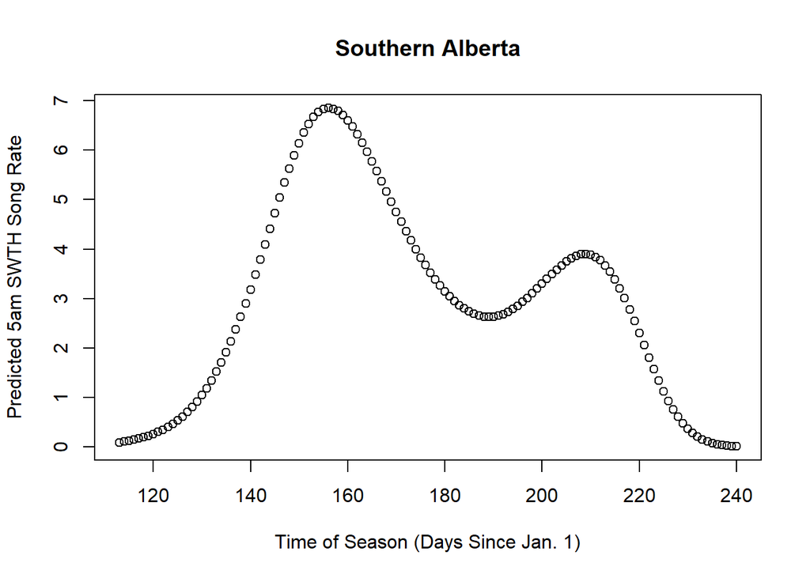

```r
plotDataS.time5<-plotData%>%
  filter(latitude.F=="S")
plotDataS.time5$timeNumeric<-5.0
plotDataS.time5$JulianDay<-JulianDay

plot(plotDataS.time5$JulianDay,
     plotDataS.time5$swth.gam.pred,
     xlab="Time of Season (Days Since Jan. 1)",
     ylab="Predicted 5am SWTH Song Rate",
     main="Southern Alberta")
```

```r
timeNumeric=seq(from=0,to=23.95,by=0.05)
JulianDay=seq(from=113,to=240,by=1)
TIME=(timeNumeric-mean(timeNumeric))/sd(timeNumeric)
JDAY=(JulianDay-mean(JulianDay))/sd(JulianDay)

#songs_per_recording[songs_per_recording$JulianDay==180,]
swth.tsss.jd2<-expand.grid(intercept=1,
                             latitude.F=c("N","S"),
                             TIME=as.numeric(levels(as.factor(TIME))),
                             JDAY=0.5162948#scaled value associated with JulianDay=180
)

#get model matrix for GAM2 based on these variables in prediction dataset
swth.tsss.jdmm2 <- model.matrix(GAM2$gam, swth.tsss.jd2)

## predict and apply inverse link function: this gives a new matrix
swth.gam.pred2 <- (exp(swth.tsss.jdmm2 %*% coef.gammB2))#take antilog?
Preds2<-data.frame(swth.gam.pred2)
```

Plot predicted relationship between Swainson’s Thrush activity over a 24-hour period (Julian Day = 180) in both northern and southern Alberta.

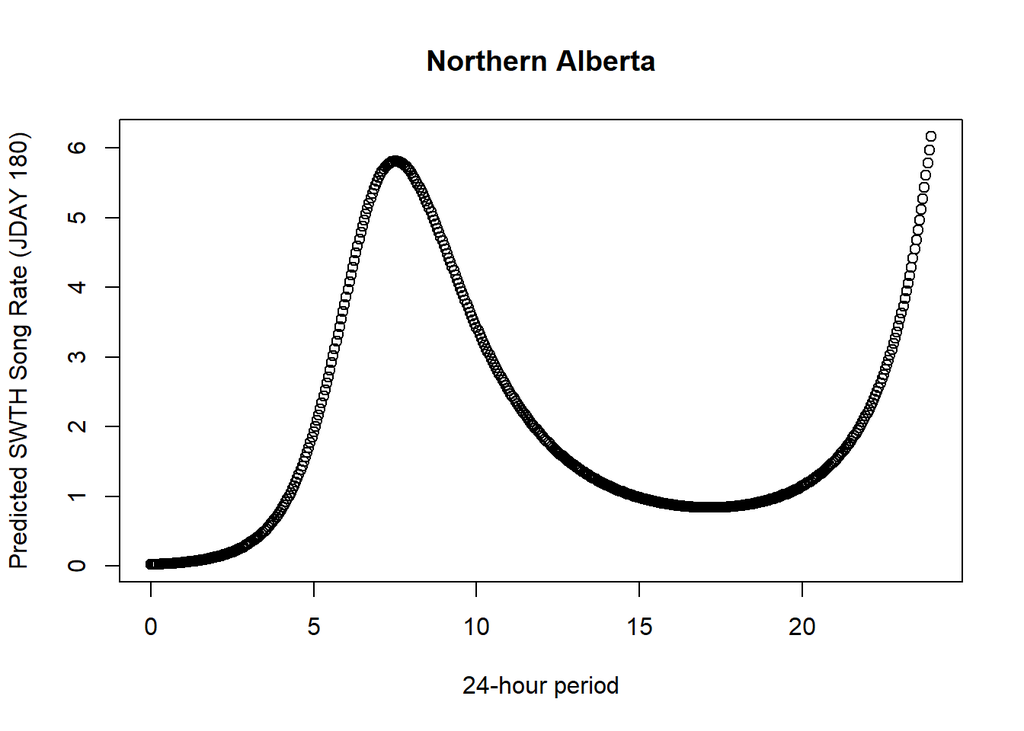

```r
plotData<-cbind(swth.tsss.jd2, Preds2)
plotData<-data.frame(plotData)
#write.csv(plotData, file="output/GAMdatacheck.csv")
plotDataN.time5<-plotData%>%
  filter(latitude.F=="N")
plotDataN.time5$timeNumeric<-timeNumeric
plotDataN.time5$JulianDay<-180

plot(plotDataN.time5$timeNumeric,
     plotDataN.time5$swth.gam.pred,
     xlab="24-hour period",
     ylab="Predicted SWTH Song Rate (JDAY 180)",
     main="Northern Alberta")
```

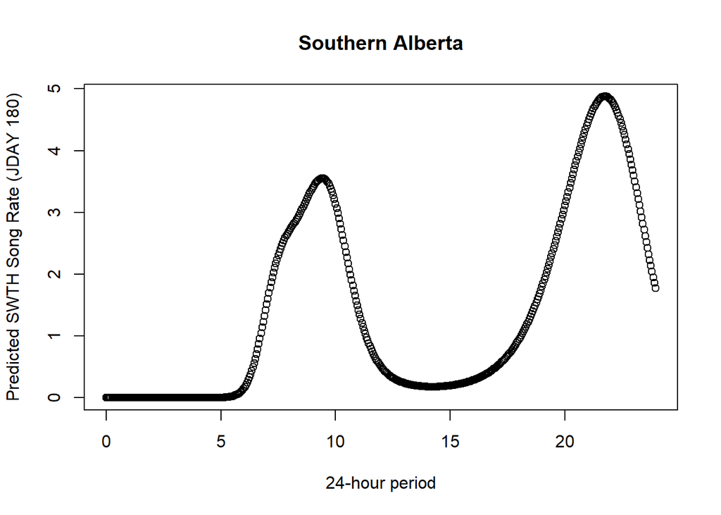

```r
plotDataS.time5<-plotData%>%
  filter(latitude.F=="S")
plotDataS.time5$timeNumeric<-timeNumeric
plotDataS.time5$JulianDay<-180

plot(plotDataS.time5$timeNumeric,
     plotDataS.time5$swth.gam.pred,
     xlab="24-hour period",
     ylab="Predicted SWTH Song Rate (JDAY 180)",
     main="Southern Alberta")
```

Predicted effects of time of day look discontinuous at extreme values (0 hrs and 23 hrs). A circular function might be better.

```r
GAM3 <- gamm4(SWTH ~latitude.F+ s(JDAY, k=3, bs = "cs", by=latitude.F) + s(TIME, k=5, bs = "cc", by=latitude.F), random=~(1|location), data=songs_per_recording, family=negbin(theta=thetaval, link="log"))
#cc=a cyclic cubic spline used for TIME
#removed the specification for the number of knots; a larger number of knots is used for both the JDAY and TIME basis functions

coef.gammB3<-coef(GAM3$gam)
#model.matrix(GAM2$gam)
coef.gammB3
```

```
##           (Intercept)           latitude.FS s(JDAY):latitude.FN.1
##            -0.1837310             0.5395662             3.7726639
## s(JDAY):latitude.FN.2 s(JDAY):latitude.FS.1 s(JDAY):latitude.FS.2
##            -7.0408397             1.0958513            -2.9543171
## s(TIME):latitude.FN.1 s(TIME):latitude.FN.2 s(TIME):latitude.FN.3
##             0.1688284            -0.4528270             0.1025207
## s(TIME):latitude.FS.1 s(TIME):latitude.FS.2 s(TIME):latitude.FS.3
##             0.9354716             0.4771812             0.3426947
```

```r
print("AIC:")
```

```
## [1] "AIC:"
```

```r
AIC(GAM1$mer, GAM2$mer, GAM3$mer)
```

```
##          df      AIC
## GAM1$mer  5 6085.371
## GAM2$mer  8 5644.204
## GAM3$mer  8 6674.963
```

```r
print("GAM3 Check:")
```

```
## [1] "GAM3 Check:"
```

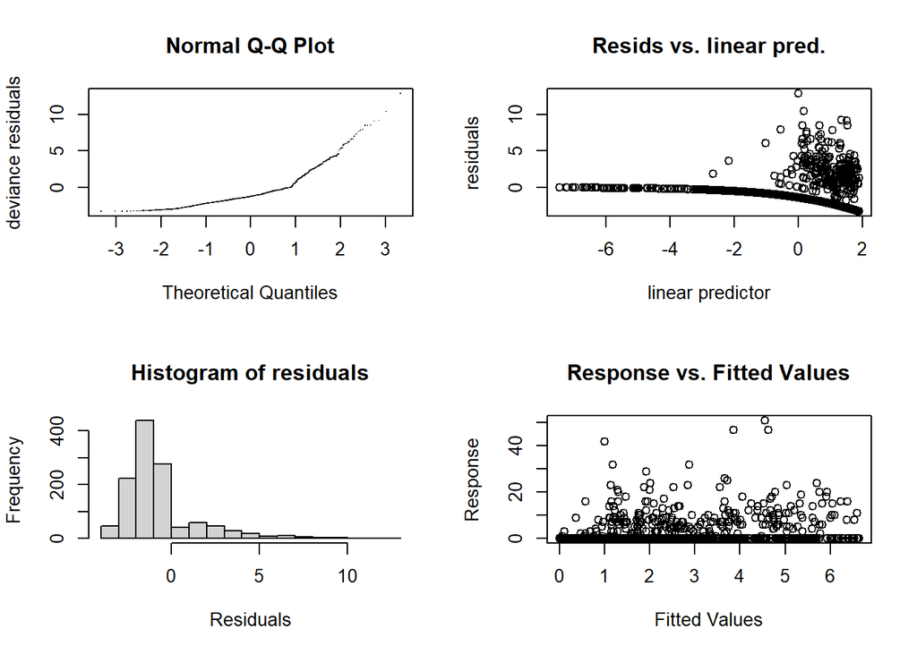

```
##
## 'gamm' based fit - care required with interpretation.
## Checks based on working residuals may be misleading.
## Basis dimension (k) checking results. Low p-value (k-index<1) may
## indicate that k is too low, especially if edf is close to k'.
##
##                       k'  edf k-index p-value
## s(JDAY):latitude.FN 2.00 2.00    0.81   0.005 **
## s(JDAY):latitude.FS 2.00 1.98    0.81  <2e-16 ***
## s(TIME):latitude.FN 3.00 2.76    0.79  <2e-16 ***
## s(TIME):latitude.FS 3.00 2.97    0.79  <2e-16 ***
## ---
## Signif. codes:  0 '***' 0.001 '**' 0.01 '*' 0.05 '.' 0.1 ' ' 1
```

```r
gam.check(GAM3$gam)
```

```r
timeNumeric=seq(from=0,to=23.95,by=0.05)
JulianDay=seq(from=113,to=240,by=1)
TIME=(timeNumeric-mean(timeNumeric))/sd(timeNumeric)
JDAY=(JulianDay-mean(JulianDay))/sd(JulianDay)

#songs_per_recording[songs_per_recording$timeNumeric==5,]
swth.tsss.jd<-expand.grid(intercept=1,
                             latitude.F=c("N","S"),
                             TIME=-0.5254806, #scaled value associated with timeNumeric=5.00
                             JDAY=as.numeric(levels(as.factor(JDAY)))
)

#get model matrix for GAM2 based on these variables in prediction dataset
swth.tsss.jdmm <- model.matrix(GAM3$gam, swth.tsss.jd)

## predict and apply inverse link function: this gives a new matrix
swth.gam.pred <- (exp(swth.tsss.jdmm %*% coef.gammB3))#take antilog?
Preds<-data.frame(swth.gam.pred)
```

Plot predicted relationship between Swainson’s Thrush activity at 5 AM over the season in both northern and southern Alberta, using a circular function for the effect of time of day/night.

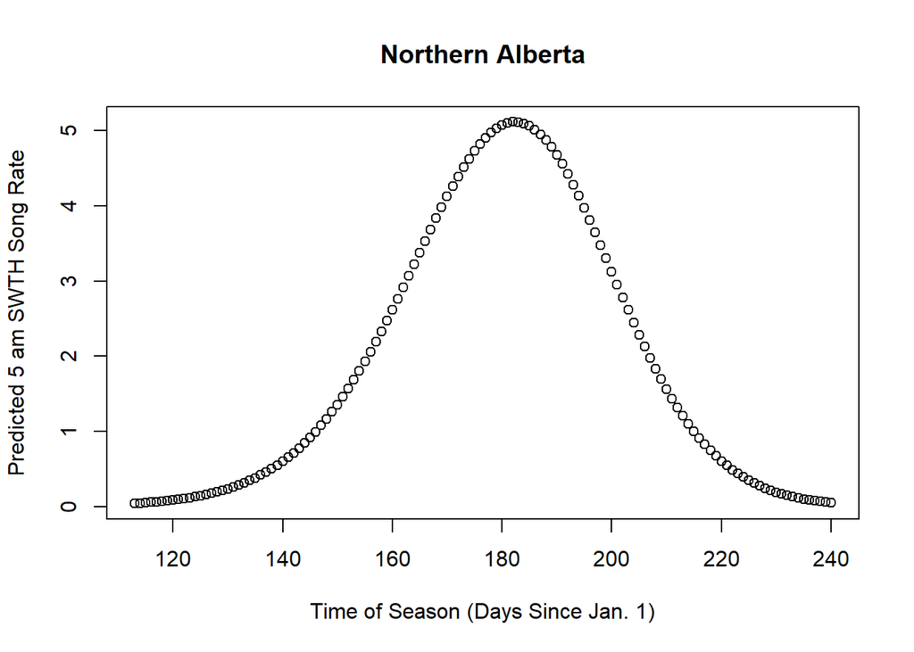

```r
plotData<-cbind(swth.tsss.jd, Preds)
plotData<-data.frame(plotData)
#write.csv(plotData, file="output/GAMdatacheck.csv")
plotDataN.time5<-plotData%>%
  filter(latitude.F=="N")
plotDataN.time5$timeNumeric<-5.0
plotDataN.time5$JulianDay<-JulianDay

plot(plotDataN.time5$JulianDay,
     plotDataN.time5$swth.gam.pred,
     xlab="Time of Season (Days Since Jan. 1)",
     ylab="Predicted 5 am SWTH Song Rate",
     main="Northern Alberta")
```

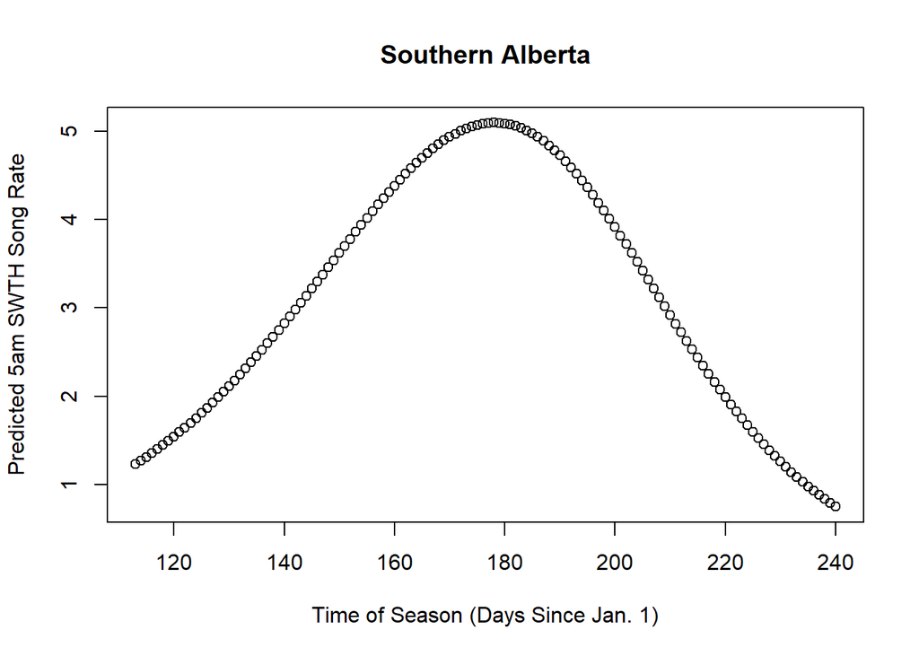

```r
plotDataS.time5<-plotData%>%
  filter(latitude.F=="S")
plotDataS.time5$timeNumeric<-5.0
plotDataS.time5$JulianDay<-JulianDay

plot(plotDataS.time5$JulianDay,
     plotDataS.time5$swth.gam.pred,
     xlab="Time of Season (Days Since Jan. 1)",
     ylab="Predicted 5am SWTH Song Rate",
     main="Southern Alberta")
```

Now plot the effect of time of day/night, using a circular function of time.

```r
timeNumeric=seq(from=0,to=23.95,by=0.05)
JulianDay=seq(from=113,to=240,by=1)
TIME=(timeNumeric-mean(timeNumeric))/sd(timeNumeric)
JDAY=(JulianDay-mean(JulianDay))/sd(JulianDay)

#songs_per_recording[songs_per_recording$JulianDay==180,]
swth.tsss.jd2<-expand.grid(intercept=1,
                             latitude.F=c("N","S"),
                             TIME=as.numeric(levels(as.factor(TIME))),
                             JDAY=0.5162948#scaled value associated with JulianDay=180
)

#get model matrix for GAM2 based on these variables in prediction dataset
swth.tsss.jdmm2 <- model.matrix(GAM3$gam, swth.tsss.jd2)

## predict and apply inverse link function: this gives a new matrix
swth.gam.pred2 <- (exp(swth.tsss.jdmm2 %*% coef.gammB3))#take antilog?
Preds2<-data.frame(swth.gam.pred2)
```

Plot predicted relationship between Swainson’s Thrush activity over a 24-hour period (Julian Day = 180) in both northern and southern Alberta, using a circular function for the effect of time.

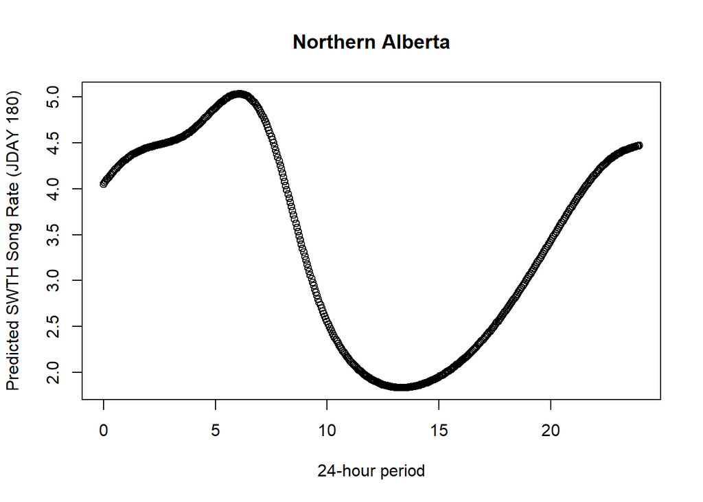

```r
plotData<-cbind(swth.tsss.jd2, Preds2)
plotData<-data.frame(plotData)
#write.csv(plotData, file="output/GAMdatacheck.csv")
plotDataN.time5<-plotData%>%
  filter(latitude.F=="N")
plotDataN.time5$timeNumeric<-timeNumeric
plotDataN.time5$JulianDay<-180

plot(plotDataN.time5$timeNumeric,
     plotDataN.time5$swth.gam.pred,
     xlab="24-hour period",
     ylab="Predicted SWTH Song Rate (JDAY 180)",
     main="Northern Alberta")
```

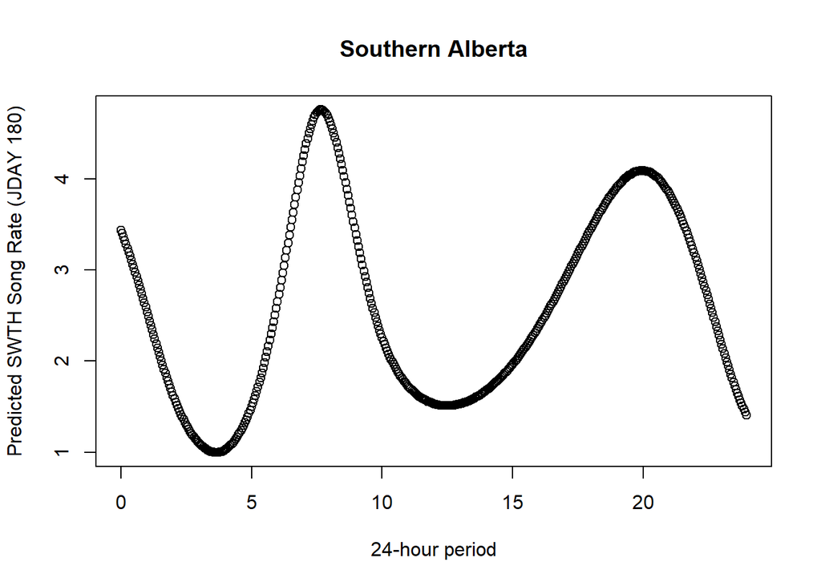

```r
plotDataS.time5<-plotData%>%
  filter(latitude.F=="S")
plotDataS.time5$timeNumeric<-timeNumeric
plotDataS.time5$JulianDay<-180

plot(plotDataS.time5$timeNumeric,
     plotDataS.time5$swth.gam.pred,
     xlab="24-hour period",
     ylab="Predicted SWTH Song Rate (JDAY 180)",
     main="Southern Alberta")
```

Try bootstrap. Note that the code chunk below has been set to *eval=FALSE*, so that it isn’t executed when the Markdown document is knitted.

```r
table(songs_per_recording$location)#4 sites with 197 - 418 recordings per site

fSampleNint <- function(dat) {
  dat %>%
    group_by(location)%>%
    sample_n(40, replace=TRUE)
}#creates a sample of 100 observations from the dataset
d1<-fSampleNint(songs_per_recording)
d2<-fSampleNint(songs_per_recording)
d3<-fSampleNint(songs_per_recording)

bs <- function(data, indices){#
  d<-fSampleNint(data)#, PKEY, 1
  #return(d$PKEY)
  thetaval<-var(d$SWTH)/mean(d$SWTH)
  try(GAM3 <- gamm4(SWTH ~latitude.F+ s(JDAY, bs = "cs", k=3, by=latitude.F) + s(TIME, k=5, bs = "cc", by=latitude.F), random=~(1|location), data=d, family=negbin(theta=thetaval, link="log")))
  try(coef.gamm<-coef(GAM3$gam))
  try(return(coef.gamm))
}
#specifying k=3 for a quadratic function (single peak) and k=5-6 for two peaks that don't necessary fall at extreme values of a predictor.
library(boot)
a<-Sys.time()
songresults <- boot(data=songs_per_recording,
                    statistic=bs, parallel="multicore",
                    R=100)
b<-Sys.time()
print(b-a)

CoefB <-t(songresults$t)
#get rid of columns with errors
CoefB<-data.frame(CoefB)
CoefB[] <- lapply(CoefB, function(x) as.numeric(as.character(x)))
#delete columns with NA values
all_na <- function(x) any(!is.na(x))
CoefB<-CoefB %>% select_if(all_na)
CoefB<-as.matrix(CoefB)
ncol(CoefB)
CoefBCI50 <- t(apply(CoefB, 1, quantile, c(0.5, 0.25, 0.75), na.rm=TRUE))
CoefBCI90 <- t(apply(CoefB, 1, quantile, c(0.5, 0.05, 0.95), na.rm=TRUE))
save(songresults, CoefB, CoefBCI50, CoefBCI90, file="output/boot100_SWTH_Aug4_3k_Julian_5k_Time.RData")
```

Plot bootstrapped model results, producing a matrix plot of song activity versus time of day/night for each combination of latitude and Julian date. Note that the code chunk below has been set to *eval=FALSE*, so that it isn’t executed when the Markdown document is knitted.

```r
load("output/boot100_SWTH_Aug4_3k_Julian_5k_Time.RData")
songs_per_recording$date<-substr(songs_per_recording$recording_date_time,1,10)
dates<-data.frame(unique(songs_per_recording[,c("date","JulianDay","JDAY")]))
date_times<-data.frame(unique(songs_per_recording[,c("date","JulianDay","JDAY","timeNumeric","TIME")]))

for (i in 1:nrow(dates)){
  Day<-dates[i,1]
  ordinal.day<-dates[i,2]
  songs.tsss.jd<-expand.grid(intercept=1,
                             latitude.F=c("N","S"),
                             timeNumeric=seq(from=0,to=23.66667,by=(1/3)),
                             JulianDay=seq(from=113,to=240,by=1)
  )
  songs.tsss.jd$JDAY<-(songs.tsss.jd$JulianDay-mean(songs.tsss.jd$JulianDay))/sd(songs.tsss.jd$JulianDay)
  songs.tsss.jd$TIME<-(songs.tsss.jd$timeNumeric-mean(songs.tsss.jd$timeNumeric))/sd(songs.tsss.jd$timeNumeric)

  #Now limit predictions to those from a single date
  songs.tsss.jd<-songs.tsss.jd[songs.tsss.jd$JulianDay==ordinal.day,]

  JulianDay<-songs.tsss.jd$JulianDay
  Latitude<-songs.tsss.jd$latitude.F
  timeNumeric<-songs.tsss.jd$timeNumeric
  str(songs.tsss.jd)
  names(songs.tsss.jd)

  songs.tsss.jdmm <- model.matrix(GAM3$gam, songs.tsss.jd)#meantemp.s+moon.s+

  ## predict and apply inverse link function: this gives an n_new x B+1 matrix
  songpreds100 <- (exp(songs.tsss.jdmm %*% CoefB))#take antilog?

  ## calculate median and 95% CIs for predictions
  bp100.CI95 <- t(apply(songpreds100, 1, quantile, seq(from=0.025, to=0.975, by=((0.975-0.025)/95)), na.rm=TRUE))

  ## Use these bootstrapped predictions to generate heat maps, 3d plots, etc.

  songs.tsss.jd.bci<-cbind(songs.tsss.jd, bp100.CI95)
  songs.tsss.jd.bci$Latitude.F<-as.factor(songs.tsss.jd.bci$latitude.F)
  songs.tsss.jd.bci$date<-Day

  latlevels<-c("N","S")
  try(for (j in 1:length(latlevels)){
    preds.sitelevel<-songs.tsss.jd.bci[songs.tsss.jd.bci$Latitude.F==latlevels[j],]
    preds.025.975<-preds.sitelevel[,7:102]
    for (k in 1:ncol(preds.025.975)){
      preds.025.975[,k]<-ifelse(preds.025.975[,k]>20,20,preds.025.975[,k])#pick a threshold value that is reasonable for a 1-minute recording, e.g. a song every 3 seconds
    }
    tiff(paste0("output/matrix plots/SWTH 3k Julian 5k Time/",ifelse(j==1,"N_","S_"),"SWTHsongrateXToD-",Day,".tiff"), units="in", width=6, height=4, res=300)
    matplot(preds.sitelevel$timeNumeric,
            preds.025.975,
            type="l", cex.axis=1.5, cex.lab=1.5,
            col="red",#cividis(100),
            xlab=paste0("Time of day (24h) ", Day),
            xlim=c(0,23.99), ylim=c(0,20),
            ylab="SWTH song rate",
            main=paste0(ifelse(j==1,"North ","South "), "Alberta"))
    dev.off()
  })
}
```